# CS5801 Coursework SUBMISSION Template Proforma

2451943

05 January, 2025

# 0. Instructions

```r
library(tidyverse)       # Used for data manipulation and visualization (includes dplyr and ggplot2)
library(skimr)           # Provides comprehensive data summaries and insights
library(ggplot2)         # Creates detailed and customizable data visualizations
library(car)             # Used for statistical modeling and multicollinearity checks (e.g., VIF calculation)
library(naniar)          # Assists in handling and visualizing missing data
library(caret)           # Facilitates data preprocessing, modeling, and validation
library(pROC)            # Generates ROC curves and calculates AUC for model evaluation
citation("pROC")
```

[output not shown]

# 1. Organise and clean the data

## 1.1 Subset the data into the specific dataset allocated

```r
# Only change the value for SID
# Assign your student id into the variable SID, for example:
SID <- 2451943                                 # This is an example, replace 2101234 with your actual ID
SIDoffset <- (SID %% 50) + 1    # Your SID mod 50 + 1

load("student_data.Rda")
# Now subseting the student data set
# Picking every 50th observation starting from your offset
mydf <- student_data_analysis[seq(from=SIDoffset,to=nrow(student_data_analysis),by=50),]
# The first rows
head(mydf)
```

|  | student_id | entry_exam_mark | sat_score | percentage_absence | free_school_meals | grade_point_average | completed.extended.project | month_of_birth | commute_method |
| --- | --- | --- | --- | --- | --- | --- | --- | --- | --- |
| 44 | 44 | 100.00 | 1310 | 2.06 | No | 3.61 | Yes | December | Bus |
| 94 | 94 | 62.12 | 702 | 9.31 | Yes | 2.42 | Yes | February | Bus |
| 144 | 144 | 37.09 | 752 | 15.38 | Yes | 1.90 | No | February | Bus |
| 194 | 194 | 66.52 | 898 | 19.09 | No | 2.18 | No | April | Bus |
| 244 | 244 | 56.06 | 912 | 14.93 | No | 1.70 | No | July | Bicycle |
| 294 | 294 | 52.88 | 999 | 5.85 | Yes | 2.26 | No | September | Walking |

```r
# Displaying the structure of the subsetted data
str(mydf)
```

```
## 'data.frame':    400 obs. of  9 variables:
##  $ student_id                : int  44 94 144 194 244 294 344 394 444 494 ...
##  $ entry_exam_mark           : num  100 62.1 37.1 66.5 56.1 ...
##  $ sat_score                 : num  1310 702 752 898 912 999 938 893 817 552 ...
##  $ percentage_absence        : num  2.06 9.31 15.38 19.09 14.93 ...
##  $ free_school_meals         : chr  "No" "Yes" "Yes" "No" ...
##  $ grade_point_average       : num  3.61 2.42 1.9 2.18 1.7 2.26 2.58 2.04 2.4 1.9 ...
##  $ completed.extended.project: chr  "Yes" "Yes" "No" "No" ...
##  $ month_of_birth            : chr  "December" "February" "February" "April" ...
##  $ commute_method            : chr  "Bus" "Bus" "Bus" "Bus" ...
```

Every 50th observation is included in the subset, which begins with an offset determined by my student ID. This method lessens bias and guarantees that the sample is distributed uniformly throughout the dataset. The following variables are present in the dataset:

1. student_id: A special number assigned to every student.
2. entry_exam_mark: The student’s entry exam score expressed as a number.
3. sat_score: a SAT score in the 200–1600 range.
4. percentage_absence: The proportion of days the pupil missed class.
5. free_school_meals: Indicates whether or not the student was given free lunches.
6. grade_point_average: A numerical representation of the student’s GPA.
7. finished.extended.project: Indicates whether or not the student finished an extended project.
8. month_of_birth: The student’s birth month.
9. commute_method: The student’s mode of transportation (e.g., walk, bus).

This subset keeps the data manageable while offering a representative sample for study.

## 1.2 Data quality plan

For analysis, a clean dataset is essential. To guarantee the quality of the data, the following actions were prepared and carried out:

1. Checking for Missing Values: Visually examining missing data in all columns using tools such as “vis_miss”. Crucial factors like “sat_score” and “grade_point_average” should receive particular attention because they have a direct bearing on the results of the research.
2. Examining Outliers: Using summary statistics to find any extreme or odd numbers in numerical columns such as “entry_exam_mark” and “percentage_absence”. To visually identify outliers, use box plots.
3. Verifying Categorical Variables: Verifying categories are consistent, particularly for variables like “commute_method”, where misspellings may result in mistakes. To keep things consistent, standardize inconsistent entries.
4. Detecting Duplicate Records: Looking for precise duplicate rows that can distort the results. i will eliminate any duplicates that are discovered.
5. Verifying Data Ranges: To find possible data input problems, I will compare numerical values (such as “sat_score” and “grade_point_average”) against expected ranges.

These procedures offer a methodical way to get the data ready for accurate and trustworthy analysis.

## 1.3 Data quality findings

After applying the plan, I found a few issues that needed attention:

### Issue 1

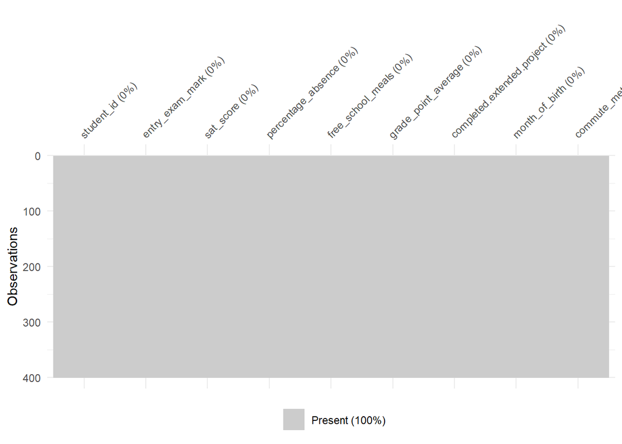

```r
# Check for missing values
vis_miss(mydf)
```

therwe are no missing values found

### Issue 2

```r
# Checking unique values in `commute_method`
unique(mydf$commute_method)
```

```
## [1] "Bus"     "Bicycle" "Walking" "Other"   "Car"     "car"     "Bicicle"
```

### Issue 3

```r
# Checking for duplicate rows
duplicates <- mydf[duplicated(mydf), ]
duplicates
```

| student_id | entry_exam_mark | sat_score | percentage_absence | free_school_meals | grade_point_average | completed.extended.project | month_of_birth | commute_method |
| --- | --- | --- | --- | --- | --- | --- | --- | --- |

The dataset had no duplicate rows. This was verified by a check, and the results showed no duplicates.

### Summary of Findings

These results demonstrate that although there are no duplicate or missing rows, several categorical variable inconsistencies must be fixed to guarantee clean data for analysis.

## 1.4 Data cleaning

I cleaned the dataset by doing the following after determining the problems with the data quality:

### Resolving Inconsistent Groups

There were spelling errors in “Bicicle” and case sensitivity problems with “car” in the `commute_method` variable. To guarantee consistency, these were fixed.

```r
# Standardize the categories in commute_method
mydf$commute_method <- dplyr::recode(mydf$commute_method,
                                     "Bicicle" = "Bicycle",
                                     "car" = "Car")
# Verify the correction
unique(mydf$commute_method)
```

```
## [1] "Bus"     "Bicycle" "Walking" "Other"   "Car"
```

### Removing Duplicate Rows

Even if the quality check did not find any duplicate rows still it is a good idea to include a procedure to eliminate them should they be discovered in subsequent rounds.

```r
# Remove duplicate rows if any exist
mydf <- mydf[!duplicated(mydf), ]
# Verify no duplicates remain
nrow(mydf)
```

```
## [1] 400
```

### Addressing Issue 3

### Verifying Data Ranges

Even though the data quality checks revealed no missing values, ongoing observation is crucial. Predictive modeling or mean/mode imputation for numerical or categorical data might be used if crucial variables have missing values that is why important numbers such as “sat_score” and “grade_point_average” were examined to make sure their values fell within the predicted ranges. Additional research or adjustment would be necessary for any numbers that fall outside of these ranges.

```r
# Summary statistics to verify data ranges
summary(mydf$sat_score)
```

```
##    Min. 1st Qu.  Median    Mean 3rd Qu.    Max.
##   453.0   860.5   979.5   987.4  1135.2  1551.0
```

```r
summary(mydf$grade_point_average)
```

```
##    Min. 1st Qu.  Median    Mean 3rd Qu.    Max.
##   1.270   2.158   2.480   2.501   2.840   3.920
```

### Summary of Cleaning

# 2. Exploratory Data Analysis (EDA)

## 2.1 EDA plan

The goal here is to examine the data in great detail and determine what is happening. My goal is to gain an understanding of the distribution of the data and identify any noteworthy trends, particularly between the dependent variables such as “grade_point_average” and the other variables in the dataset. The plan is as follows:

### Element 1

The first thing I looked at was how “grade_point_average” is spread out. I used histogram to check this.

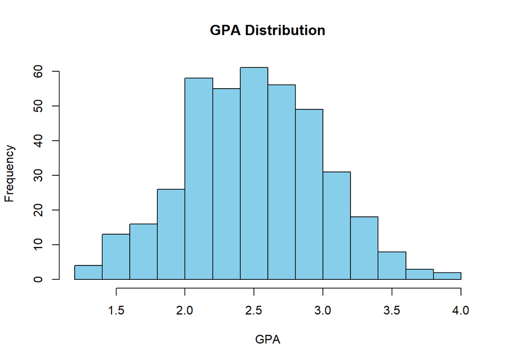

```r
# Histogram of grade_point_average
hist(mydf$grade_point_average,
     main = "GPA Distribution",
     xlab = "GPA",
     col = "skyblue",
     breaks = 10)
```

What the histogram shows: This plot highlights that most GPAs are between 2.0 and 3.0, with more than 40 observations in this range. It is useful for understanding where the majority of students are performing and identifying any unusual or extreme values.

### Element 2

Next, I checked if there is any connection between SAT scores and GPA. I used scatter plot to check correlation between SAT scores and GPA.

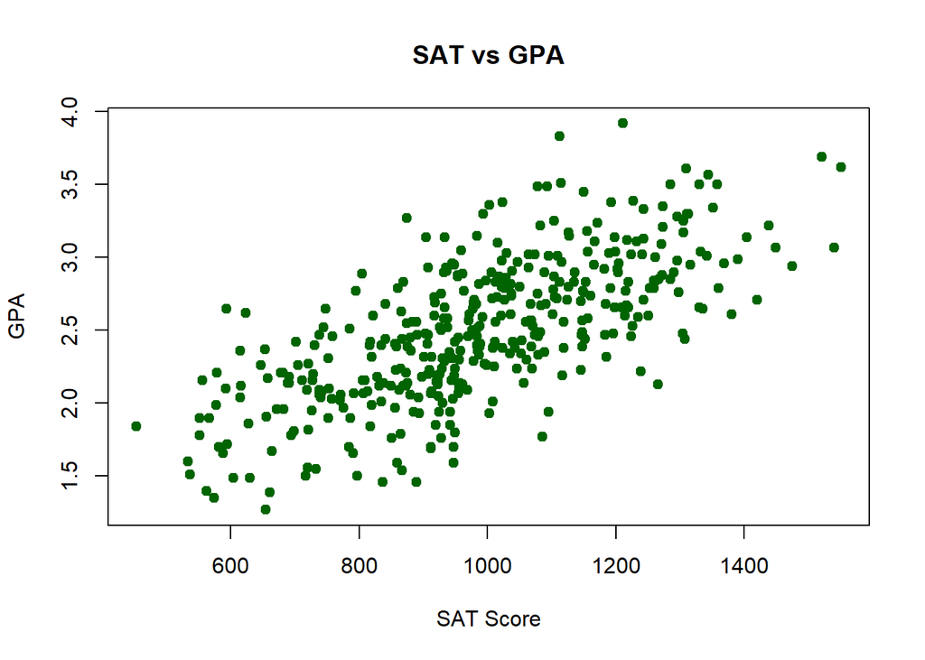

```r
# Scatter plot of sat_score vs grade_point_average
plot(mydf$sat_score, mydf$grade_point_average,
     main = "SAT vs GPA",
     xlab = "SAT Score",
     ylab = "GPA",
     col = "darkgreen",
     pch = 19)
```

What the scatter plot shows: This plot shows a positive relationship between SAT scores and GPA. It indicates that students with higher SAT scores tend to have higher GPAs, providing evidence of a link between academic aptitude and performance.

### Element 3

Finally, I wanted to see how students get to school. I used bar plot because it is perfect for showing the frequency of different commuting methods.

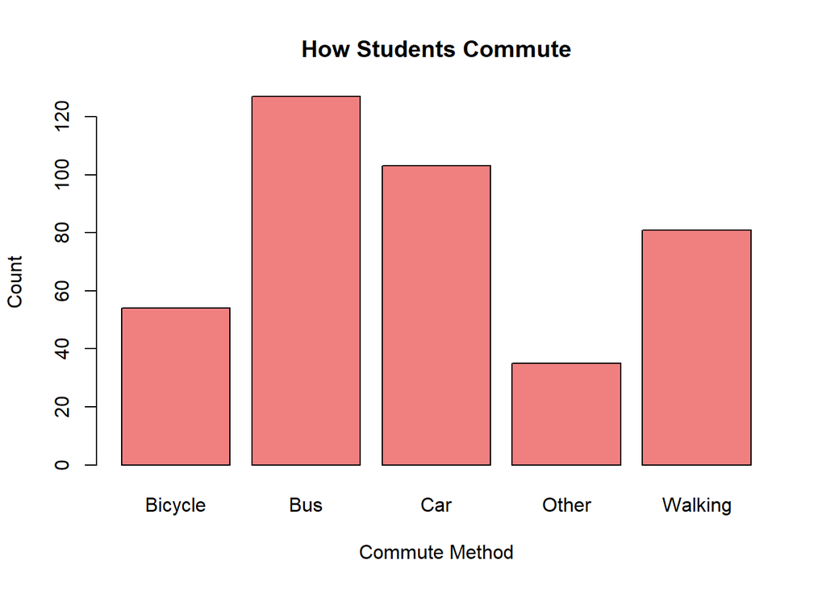

```r
# Bar plot of commute_method
barplot(table(mydf$commute_method),
        main = "How Students Commute",
        xlab = "Commute Method",
        ylab = "Count",
        col = "lightcoral")
```

# 3. Modelling

## 3.1 Explaination

The goal of this analysis is to model the variable “grade_point_average” to understand the factors that affect student performance. Here are the actions I did and the justifications behind my decisions:

### Methods Used

I used a linear regression model for this analysis because “grade_point_average” is a continuous variable, and linear regression is a straightforward and interpretable method for such cases. It allows me to assess how each independent variable contributes to changes in GPA.

### Incorporating EDA Findings

From the exploratory data analysis: 1. SAT Scores: A positive relationship between SAT scores and GPA was identified. This variable was included as a key predictor in the model. 2. Commute Method: Student performance may be impacted by various commuting strategies, whether as a result of resource accessibility or commute time. Standardization was followed by the inclusion of this category variable. 3. Absence Percentage: Academic performance is probably impacted by this variable because lower GPAs may be associated with higher absence rates.

### Addressing Weaknesses

To ensure the model was robust: - Multicollinearity Check: I calculated variance inflation factors (VIFs) to identify and address multicollinearity among predictors. - Residual Analysis: In order to verify that the linear regression assumptions were true and to check for homoscedasticity, I looked at residual plots.

### Alternative Approaches Considered

Although the main technique was linear regression, I also thought about using polynomial regression to identify any possible nonlinear correlations. The SAT and GPA scatter plot, however, indicated a linear trend, therefore a more straightforward linear model was used.

### Summary

The finished model offers an understandable and straightforward framework for figuring out what influences GPA. The study guarantees dependability and practical applicability by correcting model flaws and integrating insights from EDA.

## 3.2 Provide a model for Grade point average

“sat_score”, “percentage_absence”, and a few levels of “commute_method” were kept in the final model. The implementation is shown below:

### Proposed model

```r
# Fitting the final linear regression model
final_model <- lm(grade_point_average ~ sat_score + percentage_absence + commute_method, data = mydf)
summary(final_model)
```

```
##
## Call:
## lm(formula = grade_point_average ~ sat_score + percentage_absence +
##     commute_method, data = mydf)
##
## Residuals:
##      Min       1Q   Median       3Q      Max
## -0.67925 -0.19511 -0.02594  0.14962  1.94959
##
## Coefficients:
##                        Estimate Std. Error t value Pr(>|t|)
## (Intercept)            0.944014   0.085053  11.099   <2e-16 ***
## sat_score              0.001782   0.000074  24.081   <2e-16 ***
## percentage_absence    -0.015725   0.001332 -11.808   <2e-16 ***
## commute_methodBus     -0.037746   0.048716  -0.775   0.4389
## commute_methodCar     -0.028456   0.050955  -0.558   0.5769
## commute_methodOther   -0.158688   0.065511  -2.422   0.0159 *
## commute_methodWalking  0.002437   0.052539   0.046   0.9630
## ---
## Signif. codes:  0 '***' 0.001 '**' 0.01 '*' 0.05 '.' 0.1 ' ' 1
##
## Residual standard error: 0.2988 on 393 degrees of freedom
## Multiple R-squared:  0.6335, Adjusted R-squared:  0.6279
## F-statistic: 113.2 on 6 and 393 DF,  p-value: < 2.2e-16
```

### Proposed model diagnostics

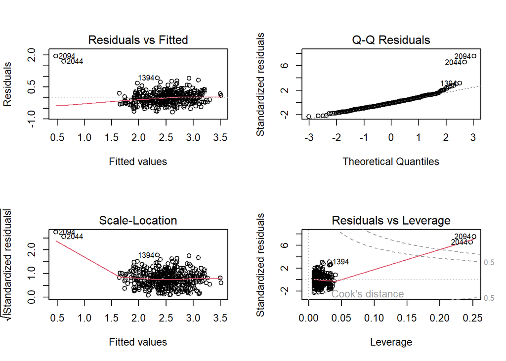

```r
# Checking residuals
par(mfrow = c(2, 2))
plot(final_model)
```

```r
# Variance Inflation Factor (VIF)
library(car)
vif(final_model)
```

```
##                        GVIF Df GVIF^(1/(2*Df))
## sat_score          1.069183  1        1.034013
## percentage_absence 1.063811  1        1.031412
## commute_method     1.048855  4        1.005980
```

### Proposed model intepretation

The linear regression model provides the following insights: 1. SAT Score: Positively correlated with GPA, indicating that higher SAT scores lead to better academic results. 2. Absence Percentage: inversely correlated, indicating that greater absences lower GPA. 3. Commute Method: When compared to the reference group, “Other” commuting methods significantly lowered GPA.

The model has a robust fit and significant predictors, accounting for 63% of the variance in GPA (Adjusted R-squared = 0.6279).

```r
#optional
```

# 4. Modelling another dependent variable

## 4.1 Modelling the Likelihood of Completing an Extended Project

### Objective

This section focuses on using logistic regression to predict if a student has finished an extended project (`completed.extended.project`). The binary target variable is Yes/No.

#### Approach

Because logistic regression works well with binary outcomes, it was chosen. To guarantee compatibility, the target variable was recoded to 0 (No) and 1 (Yes). To solve possible convergence problems and enhance model performance, predictor variables were scaled.

#### Including EDA Results:

SAT Score (“sat_score_scaled”): Added because of its noted beneficial association with academic achievement. Percentage Absence (“percentage_absence_scaled”): Added to take into consideration its probable detrimental effect on academic performance. Commute Method (“commute_method”): The possible impact of the commute method on project completion was assessed.

### Alternative Approaches:

Although decision trees were thought to capture non-linear relationships, they were not included in order to maintain the interpretability of the model. Lasso and other regularization techniques were investigated but not used because of the dataset’s simplicity.

### Proposed Model

Included as predictors in the final logistic regression model were “sat_score”, “percentage_absence”, and certain levels of “commute_method”:

```r
# Recoding target variable to binary
mydf$completed.extended.project <- ifelse(mydf$completed.extended.project == "Yes", 1, 0)

# Scaling numerical variables
mydf$sat_score_scaled <- scale(mydf$sat_score)
mydf$percentage_absence_scaled <- scale(mydf$percentage_absence)

# Fit logistic regression model
final_log_model <- glm(completed.extended.project ~ sat_score_scaled + percentage_absence_scaled + commute_method,
                       family = binomial, data = mydf, control = list(maxit = 50))
summary(final_log_model)
```

```
##
## Call:
## glm(formula = completed.extended.project ~ sat_score_scaled +
##     percentage_absence_scaled + commute_method, family = binomial,
##     data = mydf, control = list(maxit = 50))
##
## Coefficients:
##                           Estimate Std. Error z value Pr(>|z|)
## (Intercept)                 1.3010     0.3829   3.398 0.000679 ***
## sat_score_scaled            1.4861     0.1790   8.304  < 2e-16 ***
## percentage_absence_scaled  -1.4753     0.2183  -6.759 1.39e-11 ***
## commute_methodBus          -0.1592     0.4463  -0.357 0.721284
## commute_methodCar          -1.1294     0.4492  -2.514 0.011936 *
## commute_methodOther        -0.7694     0.5719  -1.345 0.178509
## commute_methodWalking       0.4253     0.5026   0.846 0.397452
## ---
## Signif. codes:  0 '***' 0.001 '**' 0.01 '*' 0.05 '.' 0.1 ' ' 1
##
## (Dispersion parameter for binomial family taken to be 1)
##
##     Null deviance: 510.13  on 399  degrees of freedom
## Residual deviance: 356.08  on 393  degrees of freedom
## AIC: 370.08
##
## Number of Fisher Scoring iterations: 5
```

```r
# Diagnostics
library(car)
vif(final_log_model)
```

```
##                               GVIF Df GVIF^(1/(2*Df))
## sat_score_scaled          1.468851  1        1.211962
## percentage_absence_scaled 1.478450  1        1.215915
## commute_method            1.032039  4        1.003950
```

### Observations and Limitations

This model does not have multicollinearity, as evidenced by the fact that all predictors’ GVIF values fall below the allowed level.

### Recommendations

# References